# Risk Factor Analysis

## Outcome Variable

**Outcome Variable:** haz

## Predictor Variables

**Intervention Variable:** fage

**Adjustment Set:**

- arm
- W_mage
- meducyrs
- feducyrs
- W_mhtcm
- W_mwtkg
- W_mbmi
- W_fhtcm
- single
- brthmon
- delta_W_mage
- delta_meducyrs
- delta_feducyrs
- delta_W_mhtcm
- delta_W_mwtkg
- delta_W_mbmi
- delta_W_fhtcm
- delta_single
- delta_brthmon

## Stratifying Variables

The analysis was stratified on these variable(s):

- agecat
- studyid
- country

## Data Summary

| agecat | studyid | country | fage | n_cell | n |
| --- | --- | --- | --- | --- | --- |
| Birth | ki0047075b-MAL-ED | BANGLADESH | >=38 | 63 | 133 |
| Birth | ki0047075b-MAL-ED | BANGLADESH | <32 | 25 | 133 |
| Birth | ki0047075b-MAL-ED | BANGLADESH | [32-38) | 45 | 133 |
| Birth | ki0047075b-MAL-ED | BRAZIL | >=38 | 6 | 18 |
| Birth | ki0047075b-MAL-ED | BRAZIL | <32 | 1 | 18 |
| Birth | ki0047075b-MAL-ED | BRAZIL | [32-38) | 11 | 18 |
| Birth | ki0047075b-MAL-ED | INDIA | >=38 | 7 | 27 |
| Birth | ki0047075b-MAL-ED | INDIA | <32 | 9 | 27 |
| Birth | ki0047075b-MAL-ED | INDIA | [32-38) | 11 | 27 |
| Birth | ki0047075b-MAL-ED | NEPAL | >=38 | 2 | 9 |
| Birth | ki0047075b-MAL-ED | NEPAL | <32 | 2 | 9 |
| Birth | ki0047075b-MAL-ED | NEPAL | [32-38) | 5 | 9 |
| Birth | ki0047075b-MAL-ED | PERU | >=38 | 23 | 69 |
| Birth | ki0047075b-MAL-ED | PERU | <32 | 22 | 69 |
| Birth | ki0047075b-MAL-ED | PERU | [32-38) | 24 | 69 |
| Birth | ki0047075b-MAL-ED | SOUTH AFRICA | >=38 | 17 | 31 |
| Birth | ki0047075b-MAL-ED | SOUTH AFRICA | <32 | 5 | 31 |
| Birth | ki0047075b-MAL-ED | SOUTH AFRICA | [32-38) | 9 | 31 |
| Birth | ki0047075b-MAL-ED | TANZANIA, UNITED REPUBLIC OF | >=38 | 19 | 46 |
| Birth | ki0047075b-MAL-ED | TANZANIA, UNITED REPUBLIC OF | <32 | 9 | 46 |
| Birth | ki0047075b-MAL-ED | TANZANIA, UNITED REPUBLIC OF | [32-38) | 18 | 46 |
| Birth | ki1000304b-SAS-CompFeed | INDIA | >=38 | 40 | 1249 |
| Birth | ki1000304b-SAS-CompFeed | INDIA | <32 | 1045 | 1249 |
| Birth | ki1000304b-SAS-CompFeed | INDIA | [32-38) | 164 | 1249 |
| Birth | ki1119695-PROBIT | BELARUS | >=38 | 606 | 13396 |
| Birth | ki1119695-PROBIT | BELARUS | <32 | 10729 | 13396 |
| Birth | ki1119695-PROBIT | BELARUS | [32-38) | 2061 | 13396 |
| Birth | ki1135781-COHORTS | GUATEMALA | >=38 | 245 | 823 |
| Birth | ki1135781-COHORTS | GUATEMALA | <32 | 380 | 823 |
| Birth | ki1135781-COHORTS | GUATEMALA | [32-38) | 198 | 823 |

[output cut: 75 more lines]

The following strata were considered:

- agecat: 24 months, studyid: ki0047075b-MAL-ED, country: BANGLADESH
- agecat: 24 months, studyid: ki0047075b-MAL-ED, country: BRAZIL
- agecat: 24 months, studyid: ki0047075b-MAL-ED, country: INDIA
- agecat: 24 months, studyid: ki0047075b-MAL-ED, country: NEPAL
- agecat: 24 months, studyid: ki0047075b-MAL-ED, country: PERU
- agecat: 24 months, studyid: ki0047075b-MAL-ED, country: SOUTH AFRICA
- agecat: 24 months, studyid: ki0047075b-MAL-ED, country: TANZANIA, UNITED REPUBLIC OF
- agecat: 24 months, studyid: ki1119695-PROBIT, country: BELARUS
- agecat: 24 months, studyid: ki1135781-COHORTS, country: GUATEMALA
- agecat: 24 months, studyid: ki1135781-COHORTS, country: PHILIPPINES
- agecat: 24 months, studyid: ki1148112-LCNI-5, country: MALAWI
- agecat: 6 months, studyid: ki0047075b-MAL-ED, country: BANGLADESH
- agecat: 6 months, studyid: ki0047075b-MAL-ED, country: BRAZIL
- agecat: 6 months, studyid: ki0047075b-MAL-ED, country: INDIA
- agecat: 6 months, studyid: ki0047075b-MAL-ED, country: NEPAL
- agecat: 6 months, studyid: ki0047075b-MAL-ED, country: PERU
- agecat: 6 months, studyid: ki0047075b-MAL-ED, country: SOUTH AFRICA
- agecat: 6 months, studyid: ki0047075b-MAL-ED, country: TANZANIA, UNITED REPUBLIC OF
- agecat: 6 months, studyid: ki1000304b-SAS-CompFeed, country: INDIA
- agecat: 6 months, studyid: ki1000304b-SAS-FoodSuppl, country: INDIA
- agecat: 6 months, studyid: ki1119695-PROBIT, country: BELARUS
- agecat: 6 months, studyid: ki1135781-COHORTS, country: GUATEMALA
- agecat: 6 months, studyid: ki1135781-COHORTS, country: PHILIPPINES
- agecat: 6 months, studyid: ki1148112-LCNI-5, country: MALAWI
- agecat: Birth, studyid: ki0047075b-MAL-ED, country: BANGLADESH
- agecat: Birth, studyid: ki0047075b-MAL-ED, country: BRAZIL
- agecat: Birth, studyid: ki0047075b-MAL-ED, country: INDIA
- agecat: Birth, studyid: ki0047075b-MAL-ED, country: NEPAL
- agecat: Birth, studyid: ki0047075b-MAL-ED, country: PERU
- agecat: Birth, studyid: ki0047075b-MAL-ED, country: SOUTH AFRICA
- agecat: Birth, studyid: ki0047075b-MAL-ED, country: TANZANIA, UNITED REPUBLIC OF
- agecat: Birth, studyid: ki1000304b-SAS-CompFeed, country: INDIA
- agecat: Birth, studyid: ki1119695-PROBIT, country: BELARUS
- agecat: Birth, studyid: ki1135781-COHORTS, country: GUATEMALA
- agecat: Birth, studyid: ki1135781-COHORTS, country: PHILIPPINES

### Dropped Strata

Some strata were dropped due to rare outcomes:

- agecat: Birth, studyid: ki0047075b-MAL-ED, country: BRAZIL
- agecat: Birth, studyid: ki0047075b-MAL-ED, country: NEPAL

## Methods Detail

We’re interested in the causal parameters $E[Y_a]$ for all values of $a \in \mathcal{A}$. These parameters represent the mean outcome if, possibly contrary to fact, we intervened to set all units to have $A=a$. Under the randomization and positivity assumptions, these are identified by the statistical parameters $\psi_a=E_W[E_{Y|A,W}(Y|A=a,W)]$. In addition, we’re interested in the mean of $Y$, $E[Y]$ under no intervention (the observed mean). We will estimate these parameters by using SuperLearner to fit the relevant likelihood factors – $E_{Y|A,W}(Y|A=a,W)$ and $p(A=a|W)$, and then updating our likelihood fit using a joint TMLE.

For unadjusted analyses ($W=\{\}$), initial likelihoods were estimated using Lrnr_glm to estimate the simple $E(Y|A)$ and Lrnr_mean to estimate $p(A)$. For adjusted analyses, a small library containing Lrnr_glmnet, Lrnr_xgboost, and Lrnr_mean was used.

Having estimated these parameters, we will then use the delta method to estimate relative risks and attributable risks relative to a prespecified baseline level of $A$.

# Results Detail

## Results Plots

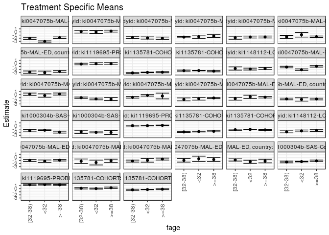

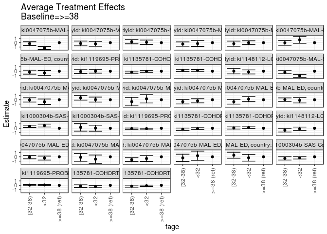

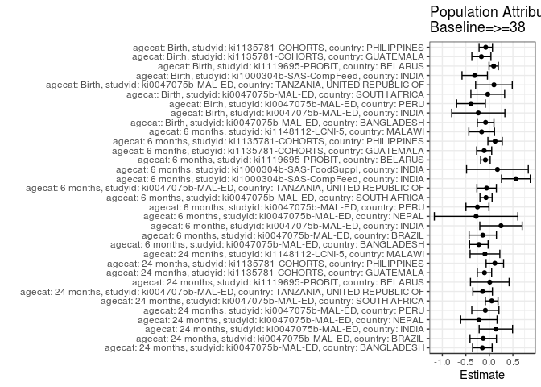

## Results Table

### Parameter: TSM

| agecat | studyid | country | intervention_level | baseline_level | estimate | ci_lower | ci_upper |
| --- | --- | --- | --- | --- | --- | --- | --- |
| Birth | ki0047075b-MAL-ED | BANGLADESH | >=38 | NA | -0.9302748 | -1.1692290 | -0.6913206 |
| Birth | ki0047075b-MAL-ED | BANGLADESH | <32 | NA | -1.2251611 | -1.6191908 | -0.8311315 |
| Birth | ki0047075b-MAL-ED | BANGLADESH | [32-38) | NA | -1.0034864 | -1.3105213 | -0.6964516 |
| Birth | ki0047075b-MAL-ED | INDIA | >=38 | NA | -1.1171429 | -1.6489224 | -0.5853634 |
| Birth | ki0047075b-MAL-ED | INDIA | <32 | NA | -1.6666667 | -2.4558740 | -0.8774593 |
| Birth | ki0047075b-MAL-ED | INDIA | [32-38) | NA | -1.2445455 | -1.9691474 | -0.5199435 |
| Birth | ki0047075b-MAL-ED | PERU | >=38 | NA | -0.5431884 | -0.8548248 | -0.2315519 |
| Birth | ki0047075b-MAL-ED | PERU | <32 | NA | -0.9439490 | -1.5485942 | -0.3393037 |
| Birth | ki0047075b-MAL-ED | PERU | [32-38) | NA | -1.2007765 | -1.5210491 | -0.8805040 |
| Birth | ki0047075b-MAL-ED | SOUTH AFRICA | >=38 | NA | -0.7005882 | -1.3189739 | -0.0822026 |
| Birth | ki0047075b-MAL-ED | SOUTH AFRICA | <32 | NA | -0.4560000 | -1.3078853 | 0.3958853 |
| Birth | ki0047075b-MAL-ED | SOUTH AFRICA | [32-38) | NA | -0.9533333 | -1.5323681 | -0.3742986 |
| Birth | ki0047075b-MAL-ED | TANZANIA, UNITED REPUBLIC OF | >=38 | NA | -1.1921053 | -1.7757068 | -0.6085037 |
| Birth | ki0047075b-MAL-ED | TANZANIA, UNITED REPUBLIC OF | <32 | NA | -1.4211111 | -1.9248904 | -0.9173319 |
| Birth | ki0047075b-MAL-ED | TANZANIA, UNITED REPUBLIC OF | [32-38) | NA | -0.8288889 | -1.1916650 | -0.4661127 |
| Birth | ki1000304b-SAS-CompFeed | INDIA | >=38 | NA | -1.1191180 | -1.3708200 | -0.8674161 |
| Birth | ki1000304b-SAS-CompFeed | INDIA | <32 | NA | -1.3666939 | -1.4728651 | -1.2605227 |
| Birth | ki1000304b-SAS-CompFeed | INDIA | [32-38) | NA | -1.4884439 | -1.7560242 | -1.2208637 |
| Birth | ki1119695-PROBIT | BELARUS | >=38 | NA | 1.2442554 | 1.1154077 | 1.3731032 |
| Birth | ki1119695-PROBIT | BELARUS | <32 | NA | 1.3292970 | 1.1755429 | 1.4830512 |
| Birth | ki1119695-PROBIT | BELARUS | [32-38) | NA | 1.2945422 | 1.1053851 | 1.4836994 |
| Birth | ki1135781-COHORTS | GUATEMALA | >=38 | NA | 0.3072436 | 0.0909595 | 0.5235278 |
| Birth | ki1135781-COHORTS | GUATEMALA | <32 | NA | 0.0337143 | -0.1287373 | 0.1961659 |
| Birth | ki1135781-COHORTS | GUATEMALA | [32-38) | NA | 0.1205097 | -0.0843625 | 0.3253818 |
| Birth | ki1135781-COHORTS | PHILIPPINES | >=38 | NA | -0.1706796 | -0.3155211 | -0.0258382 |
| Birth | ki1135781-COHORTS | PHILIPPINES | <32 | NA | -0.2732000 | -0.3322026 | -0.2141974 |
| Birth | ki1135781-COHORTS | PHILIPPINES | [32-38) | NA | -0.3588723 | -0.5411521 | -0.1765926 |
| 6 months | ki0047075b-MAL-ED | BANGLADESH | >=38 | NA | -0.9740964 | -1.2105404 | -0.7376524 |
| 6 months | ki0047075b-MAL-ED | BANGLADESH | <32 | NA | -2.0530640 | -2.3075242 | -1.7986037 |
| 6 months | ki0047075b-MAL-ED | BANGLADESH | [32-38) | NA | -1.2016253 | -1.4470000 | -0.9562506 |

[output cut: 69 more lines]

### Parameter: E(Y)

| agecat | studyid | country | intervention_level | baseline_level | estimate | ci_lower | ci_upper |
| --- | --- | --- | --- | --- | --- | --- | --- |
| Birth | ki0047075b-MAL-ED | BANGLADESH | NA | NA | -1.0100752 | -1.1744939 | -0.8456565 |
| Birth | ki0047075b-MAL-ED | INDIA | NA | NA | -1.3522222 | -1.7800602 | -0.9243843 |
| Birth | ki0047075b-MAL-ED | PERU | NA | NA | -0.9334783 | -1.1468994 | -0.7200571 |
| Birth | ki0047075b-MAL-ED | SOUTH AFRICA | NA | NA | -0.7345161 | -1.1414567 | -0.3275756 |
| Birth | ki0047075b-MAL-ED | TANZANIA, UNITED REPUBLIC OF | NA | NA | -1.0947826 | -1.3988341 | -0.7907311 |
| Birth | ki1000304b-SAS-CompFeed | INDIA | NA | NA | -1.4300160 | -1.5090211 | -1.3510109 |
| Birth | ki1119695-PROBIT | BELARUS | NA | NA | 1.3357428 | 1.1757840 | 1.4957016 |
| Birth | ki1135781-COHORTS | GUATEMALA | NA | NA | 0.1377035 | 0.0520086 | 0.2233984 |
| Birth | ki1135781-COHORTS | PHILIPPINES | NA | NA | -0.2468988 | -0.2865742 | -0.2072233 |
| 6 months | ki0047075b-MAL-ED | BANGLADESH | NA | NA | -1.1976000 | -1.3310224 | -1.0641776 |
| 6 months | ki0047075b-MAL-ED | BRAZIL | NA | NA | 0.0554008 | -0.1690575 | 0.2798592 |
| 6 months | ki0047075b-MAL-ED | INDIA | NA | NA | -1.1772360 | -1.3224216 | -1.0320505 |
| 6 months | ki0047075b-MAL-ED | NEPAL | NA | NA | -0.7256962 | -0.9111717 | -0.5402207 |
| 6 months | ki0047075b-MAL-ED | PERU | NA | NA | -1.3335141 | -1.5408101 | -1.1262180 |
| 6 months | ki0047075b-MAL-ED | SOUTH AFRICA | NA | NA | -0.9083333 | -1.1234247 | -0.6932420 |
| 6 months | ki0047075b-MAL-ED | TANZANIA, UNITED REPUBLIC OF | NA | NA | -1.4744833 | -1.6639782 | -1.2849884 |
| 6 months | ki1000304b-SAS-CompFeed | INDIA | NA | NA | -1.4006377 | -1.4802862 | -1.3209891 |
| 6 months | ki1000304b-SAS-FoodSuppl | INDIA | NA | NA | -1.8986842 | -2.0118892 | -1.7854792 |
| 6 months | ki1119695-PROBIT | BELARUS | NA | NA | 0.1166130 | 0.0230160 | 0.2102100 |
| 6 months | ki1135781-COHORTS | GUATEMALA | NA | NA | -1.8068353 | -1.8758487 | -1.7378219 |
| 6 months | ki1135781-COHORTS | PHILIPPINES | NA | NA | -1.1421265 | -1.1845116 | -1.0997415 |
| 6 months | ki1148112-LCNI-5 | MALAWI | NA | NA | -1.6211321 | -1.8052501 | -1.4370141 |
| 24 months | ki0047075b-MAL-ED | BANGLADESH | NA | NA | -1.9894040 | -2.1310968 | -1.8477111 |
| 24 months | ki0047075b-MAL-ED | BRAZIL | NA | NA | 0.1370886 | -0.0872159 | 0.3613931 |
| 24 months | ki0047075b-MAL-ED | INDIA | NA | NA | -1.8784783 | -2.0301474 | -1.7268092 |
| 24 months | ki0047075b-MAL-ED | NEPAL | NA | NA | -1.5492405 | -1.7384624 | -1.3600186 |
| 24 months | ki0047075b-MAL-ED | PERU | NA | NA | -1.7029114 | -1.8930361 | -1.5127867 |
| 24 months | ki0047075b-MAL-ED | SOUTH AFRICA | NA | NA | -1.4898315 | -1.7035677 | -1.2760952 |
| 24 months | ki0047075b-MAL-ED | TANZANIA, UNITED REPUBLIC OF | NA | NA | -2.7648500 | -2.9586982 | -2.5710018 |
| 24 months | ki1119695-PROBIT | BELARUS | NA | NA | -0.1254844 | -0.4225624 | 0.1715937 |
| 24 months | ki1135781-COHORTS | GUATEMALA | NA | NA | -2.9828012 | -3.0482527 | -2.9173497 |
| 24 months | ki1135781-COHORTS | PHILIPPINES | NA | NA | -2.4204386 | -2.4659064 | -2.3749708 |
| 24 months | ki1148112-LCNI-5 | MALAWI | NA | NA | -1.7832432 | -1.9856110 | -1.5808754 |

### Parameter: ATE

| agecat | studyid | country | intervention_level | baseline_level | estimate | ci_lower | ci_upper |
| --- | --- | --- | --- | --- | --- | --- | --- |
| Birth | ki0047075b-MAL-ED | BANGLADESH | >=38 | >=38 | 0.0000000 | 0.0000000 | 0.0000000 |
| Birth | ki0047075b-MAL-ED | BANGLADESH | <32 | >=38 | -0.2948864 | -0.7564899 | 0.1667172 |
| Birth | ki0047075b-MAL-ED | BANGLADESH | [32-38) | >=38 | -0.0732116 | -0.4616190 | 0.3151958 |
| Birth | ki0047075b-MAL-ED | INDIA | >=38 | >=38 | 0.0000000 | 0.0000000 | 0.0000000 |
| Birth | ki0047075b-MAL-ED | INDIA | <32 | >=38 | -0.5495238 | -1.5011738 | 0.4021262 |
| Birth | ki0047075b-MAL-ED | INDIA | [32-38) | >=38 | -0.1274026 | -1.0262004 | 0.7713952 |
| Birth | ki0047075b-MAL-ED | PERU | >=38 | >=38 | 0.0000000 | 0.0000000 | 0.0000000 |
| Birth | ki0047075b-MAL-ED | PERU | <32 | >=38 | -0.4007606 | -1.0830018 | 0.2814807 |
| Birth | ki0047075b-MAL-ED | PERU | [32-38) | >=38 | -0.6575881 | -1.1073990 | -0.2077773 |
| Birth | ki0047075b-MAL-ED | SOUTH AFRICA | >=38 | >=38 | 0.0000000 | 0.0000000 | 0.0000000 |
| Birth | ki0047075b-MAL-ED | SOUTH AFRICA | <32 | >=38 | 0.2445882 | -0.8080795 | 1.2972560 |
| Birth | ki0047075b-MAL-ED | SOUTH AFRICA | [32-38) | >=38 | -0.2527451 | -1.0999063 | 0.5944161 |
| Birth | ki0047075b-MAL-ED | TANZANIA, UNITED REPUBLIC OF | >=38 | >=38 | 0.0000000 | 0.0000000 | 0.0000000 |
| Birth | ki0047075b-MAL-ED | TANZANIA, UNITED REPUBLIC OF | <32 | >=38 | -0.2290058 | -0.9999691 | 0.5419574 |
| Birth | ki0047075b-MAL-ED | TANZANIA, UNITED REPUBLIC OF | [32-38) | >=38 | 0.3632164 | -0.3239497 | 1.0503825 |
| Birth | ki1000304b-SAS-CompFeed | INDIA | >=38 | >=38 | 0.0000000 | 0.0000000 | 0.0000000 |
| Birth | ki1000304b-SAS-CompFeed | INDIA | <32 | >=38 | -0.2475759 | -0.5141574 | 0.0190057 |
| Birth | ki1000304b-SAS-CompFeed | INDIA | [32-38) | >=38 | -0.3693259 | -0.7549031 | 0.0162513 |
| Birth | ki1119695-PROBIT | BELARUS | >=38 | >=38 | 0.0000000 | 0.0000000 | 0.0000000 |
| Birth | ki1119695-PROBIT | BELARUS | <32 | >=38 | 0.0850416 | -0.0105142 | 0.1805974 |
| Birth | ki1119695-PROBIT | BELARUS | [32-38) | >=38 | 0.0502868 | -0.0925671 | 0.1931407 |
| Birth | ki1135781-COHORTS | GUATEMALA | >=38 | >=38 | 0.0000000 | 0.0000000 | 0.0000000 |
| Birth | ki1135781-COHORTS | GUATEMALA | <32 | >=38 | -0.2735293 | -0.5439748 | -0.0030838 |
| Birth | ki1135781-COHORTS | GUATEMALA | [32-38) | >=38 | -0.1867340 | -0.4849631 | 0.1114951 |
| Birth | ki1135781-COHORTS | PHILIPPINES | >=38 | >=38 | 0.0000000 | 0.0000000 | 0.0000000 |
| Birth | ki1135781-COHORTS | PHILIPPINES | <32 | >=38 | -0.1025204 | -0.2586202 | 0.0535794 |
| Birth | ki1135781-COHORTS | PHILIPPINES | [32-38) | >=38 | -0.1881927 | -0.4210373 | 0.0446519 |
| 6 months | ki0047075b-MAL-ED | BANGLADESH | >=38 | >=38 | 0.0000000 | 0.0000000 | 0.0000000 |
| 6 months | ki0047075b-MAL-ED | BANGLADESH | <32 | >=38 | -1.0789675 | -1.4263067 | -0.7316284 |
| 6 months | ki0047075b-MAL-ED | BANGLADESH | [32-38) | >=38 | -0.2275289 | -0.5700079 | 0.1149501 |

[output cut: 69 more lines]

### Parameter: PAR

| agecat | studyid | country | intervention_level | baseline_level | estimate | ci_lower | ci_upper |
| --- | --- | --- | --- | --- | --- | --- | --- |
| Birth | ki0047075b-MAL-ED | BANGLADESH | >=38 | NA | -0.0798004 | -0.2563315 | 0.0967307 |
| Birth | ki0047075b-MAL-ED | INDIA | >=38 | NA | -0.2350794 | -0.8000601 | 0.3299013 |
| Birth | ki0047075b-MAL-ED | PERU | >=38 | NA | -0.3902899 | -0.6953952 | -0.0851845 |
| Birth | ki0047075b-MAL-ED | SOUTH AFRICA | >=38 | NA | -0.0339279 | -0.3925281 | 0.3246723 |
| Birth | ki0047075b-MAL-ED | TANZANIA, UNITED REPUBLIC OF | >=38 | NA | 0.0973227 | -0.2921391 | 0.4867844 |
| Birth | ki1000304b-SAS-CompFeed | INDIA | >=38 | NA | -0.3108980 | -0.5813023 | -0.0404936 |
| Birth | ki1119695-PROBIT | BELARUS | >=38 | NA | 0.0914873 | -0.0070597 | 0.1900343 |
| Birth | ki1135781-COHORTS | GUATEMALA | >=38 | NA | -0.1695401 | -0.3725336 | 0.0334533 |
| Birth | ki1135781-COHORTS | PHILIPPINES | >=38 | NA | -0.0762191 | -0.2184147 | 0.0659765 |
| 6 months | ki0047075b-MAL-ED | BANGLADESH | >=38 | NA | -0.2235036 | -0.4206393 | -0.0263679 |
| 6 months | ki0047075b-MAL-ED | BRAZIL | >=38 | NA | -0.1404874 | -0.4312470 | 0.1502722 |
| 6 months | ki0047075b-MAL-ED | INDIA | >=38 | NA | 0.2470620 | -0.2031355 | 0.6972595 |
| 6 months | ki0047075b-MAL-ED | NEPAL | >=38 | NA | -0.2821042 | -1.1699595 | 0.6057512 |
| 6 months | ki0047075b-MAL-ED | PERU | >=38 | NA | -0.2531979 | -0.4981360 | -0.0082598 |
| 6 months | ki0047075b-MAL-ED | SOUTH AFRICA | >=38 | NA | -0.0709375 | -0.1999633 | 0.0580883 |
| 6 months | ki0047075b-MAL-ED | TANZANIA, UNITED REPUBLIC OF | >=38 | NA | -0.0580184 | -0.2647363 | 0.1486996 |
| 6 months | ki1000304b-SAS-CompFeed | INDIA | >=38 | NA | 0.5643341 | 0.2584975 | 0.8701707 |
| 6 months | ki1000304b-SAS-FoodSuppl | INDIA | >=38 | NA | 0.1708815 | -0.4851195 | 0.8268826 |
| 6 months | ki1119695-PROBIT | BELARUS | >=38 | NA | -0.0838689 | -0.1848979 | 0.0171601 |
| 6 months | ki1135781-COHORTS | GUATEMALA | >=38 | NA | -0.1102485 | -0.2701289 | 0.0496319 |
| 6 months | ki1135781-COHORTS | PHILIPPINES | >=38 | NA | 0.1216996 | -0.0309610 | 0.2743602 |
| 6 months | ki1148112-LCNI-5 | MALAWI | >=38 | NA | -0.1638050 | -0.4363654 | 0.1087554 |
| 24 months | ki0047075b-MAL-ED | BANGLADESH | >=38 | NA | -0.1486684 | -0.3562956 | 0.0589588 |
| 24 months | ki0047075b-MAL-ED | BRAZIL | >=38 | NA | -0.1306114 | -0.4117708 | 0.1505479 |
| 24 months | ki0047075b-MAL-ED | INDIA | >=38 | NA | 0.1382878 | -0.2168071 | 0.4933827 |
| 24 months | ki0047075b-MAL-ED | NEPAL | >=38 | NA | -0.2229059 | -0.6097116 | 0.1638997 |
| 24 months | ki0047075b-MAL-ED | PERU | >=38 | NA | -0.0852203 | -0.3738367 | 0.2033961 |
| 24 months | ki0047075b-MAL-ED | SOUTH AFRICA | >=38 | NA | 0.0493993 | -0.0849818 | 0.1837804 |
| 24 months | ki0047075b-MAL-ED | TANZANIA, UNITED REPUBLIC OF | >=38 | NA | -0.1429135 | -0.3505894 | 0.0647623 |
| 24 months | ki1119695-PROBIT | BELARUS | >=38 | NA | 0.0090374 | -0.4018431 | 0.4199179 |
| 24 months | ki1135781-COHORTS | GUATEMALA | >=38 | NA | -0.1038400 | -0.2564432 | 0.0487633 |
| 24 months | ki1135781-COHORTS | PHILIPPINES | >=38 | NA | 0.1161607 | -0.0694494 | 0.3017707 |
| 24 months | ki1148112-LCNI-5 | MALAWI | >=38 | NA | -0.0936922 | -0.4099811 | 0.2225967 |